# Computing Dynamic SWATH Windows

Witold E. Wolski, Bernd Roschitzki

2021-12-07

# Introduction

Function optimizes Extraction windows for DIA/SWATH so we have the same number of precursor per window. This optimization is based on spectral library data or non redundant .blib files (Bibliospec).

# Constant with method

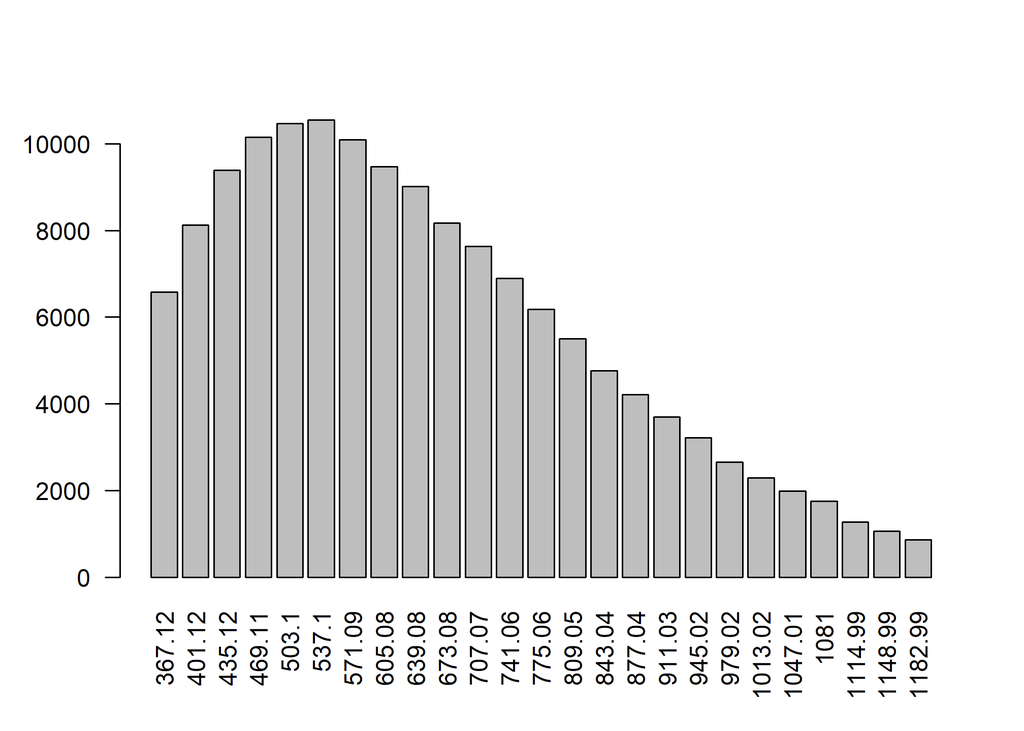

```r
data("masses")
cdsw <- Cdsw(masses , nbins = 25, digits = 1)
cdsw$plot()
```

```r
knitr::kable(cdsw$asTable())
```

| from | to | mid | width | counts |
| --- | --- | --- | --- | --- |
| 349.63 | 384.62 | 367.125 | 34.99 | 6688 |
| 383.62 | 418.62 | 401.120 | 35.00 | 8357 |
| 417.62 | 452.61 | 435.115 | 34.99 | 9661 |
| 451.61 | 486.61 | 469.110 | 35.00 | 10452 |
| 485.61 | 520.60 | 503.105 | 34.99 | 10725 |
| 519.60 | 554.59 | 537.095 | 34.99 | 10837 |
| 553.59 | 588.59 | 571.090 | 35.00 | 10433 |
| 587.59 | 622.58 | 605.085 | 34.99 | 9750 |
| 621.58 | 656.58 | 639.080 | 35.00 | 9276 |
| 655.58 | 690.57 | 673.075 | 34.99 | 8406 |
| 689.57 | 724.56 | 707.065 | 34.99 | 7848 |
| 723.56 | 758.56 | 741.060 | 35.00 | 7116 |
| 757.56 | 792.55 | 775.055 | 34.99 | 6355 |
| 791.55 | 826.55 | 809.050 | 35.00 | 5666 |
| 825.55 | 860.54 | 843.045 | 34.99 | 4923 |
| 859.54 | 894.53 | 877.035 | 34.99 | 4359 |
| 893.53 | 928.53 | 911.030 | 35.00 | 3807 |
| 927.53 | 962.52 | 945.025 | 34.99 | 3344 |
| 961.52 | 996.52 | 979.020 | 35.00 | 2724 |
| 995.52 | 1030.51 | 1013.015 | 34.99 | 2357 |
| 1029.51 | 1064.50 | 1047.005 | 34.99 | 2042 |
| 1063.50 | 1098.50 | 1081.000 | 35.00 | 1807 |
| 1097.50 | 1132.49 | 1114.995 | 34.99 | 1313 |
| 1131.49 | 1166.49 | 1148.990 | 35.00 | 1088 |
| 1165.49 | 1200.48 | 1182.985 | 34.99 | 881 |

```r
constError <- cdsw$error()
```

# Classical Method based on `quantile`

Same number of MS1 precursors in each window

```r
cdsw$quantile_breaks()
```

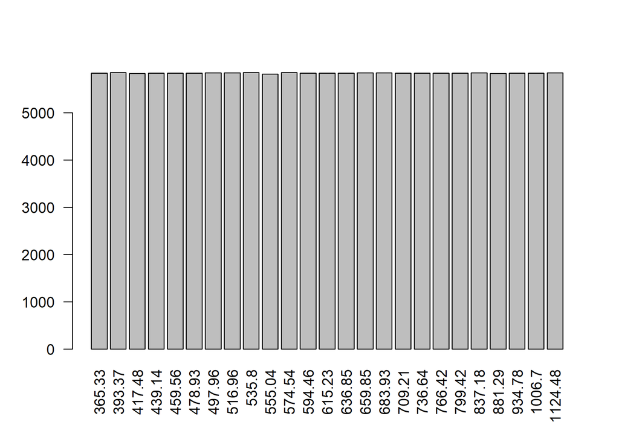

```r
cdsw$plot()
```

```r
knitr::kable(cdsw$asTable())
```

|  | from | to | mid | width | counts |
| --- | --- | --- | --- | --- | --- |
| 0% | 349.63 | 381.03 | 365.330 | 31.40 | 5956 |
| 4% | 380.03 | 406.71 | 393.370 | 26.68 | 6131 |
| 8% | 405.71 | 429.24 | 417.475 | 23.53 | 6070 |
| 12% | 428.24 | 450.05 | 439.145 | 21.81 | 6086 |
| 16% | 449.05 | 470.06 | 459.555 | 21.01 | 6095 |
| 20% | 469.06 | 488.80 | 478.930 | 19.74 | 6107 |
| 24% | 487.80 | 508.12 | 497.960 | 20.32 | 6173 |
| 28% | 507.12 | 526.81 | 516.965 | 19.69 | 6150 |
| 32% | 525.81 | 545.79 | 535.800 | 19.98 | 6166 |
| 36% | 544.79 | 565.29 | 555.040 | 20.50 | 6123 |
| 40% | 564.29 | 584.80 | 574.545 | 20.51 | 6139 |
| 44% | 583.80 | 605.12 | 594.460 | 21.32 | 6121 |
| 48% | 604.12 | 626.34 | 615.230 | 22.22 | 6113 |
| 52% | 625.34 | 648.36 | 636.850 | 23.02 | 6108 |
| 56% | 647.36 | 672.34 | 659.850 | 24.98 | 6074 |
| 60% | 671.34 | 696.53 | 683.935 | 25.19 | 6082 |
| 64% | 695.53 | 722.89 | 709.210 | 27.36 | 6054 |
| 68% | 721.89 | 751.40 | 736.645 | 29.51 | 6053 |
| 72% | 750.40 | 782.43 | 766.415 | 32.03 | 6023 |
| 76% | 781.43 | 817.40 | 799.415 | 35.97 | 5982 |
| 80% | 816.40 | 857.96 | 837.180 | 41.56 | 6026 |
| 84% | 856.96 | 905.62 | 881.290 | 48.66 | 5971 |
| 88% | 904.62 | 964.93 | 934.775 | 60.31 | 5943 |
| 92% | 963.93 | 1049.48 | 1006.705 | 85.55 | 5903 |
| 96% | 1048.48 | 1200.48 | 1124.480 | 152.00 | 5863 |

```r
quantileError <- cdsw$error()
```

# Adjust windows

Using this method the window start and end is shifted to a mass range with as few MS1 peaks as possible.

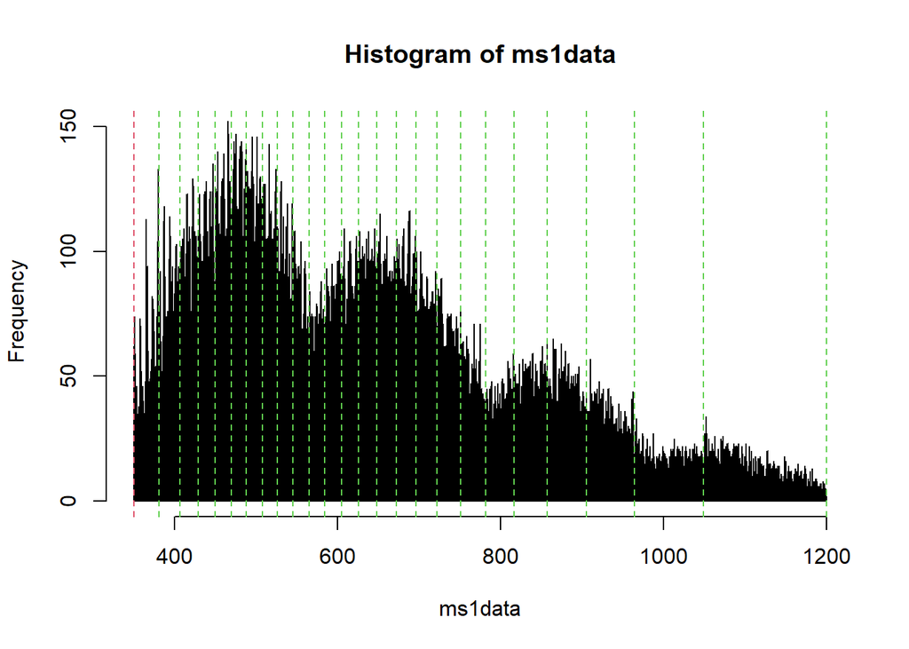

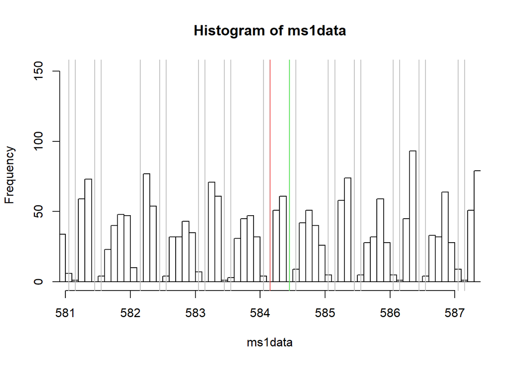

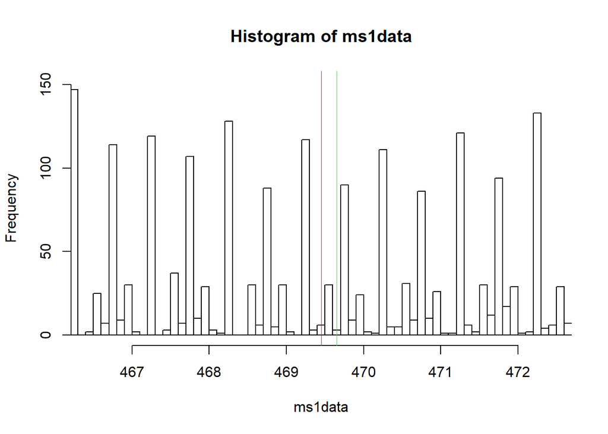

| from | to | mid | width | counts |
| --- | --- | --- | --- | --- |
| 350.13 | 380.95 | 365.54 | 30.82 | 5952 |
| 380.45 | 406.35 | 393.40 | 25.90 | 5932 |
| 406.05 | 429.05 | 417.55 | 23.00 | 5948 |
| 428.65 | 449.65 | 439.15 | 21.00 | 5891 |
| 449.45 | 469.65 | 459.55 | 20.20 | 5872 |
| 469.45 | 488.35 | 478.90 | 18.90 | 5860 |
| 488.15 | 508.05 | 498.10 | 19.90 | 6137 |
| 507.45 | 526.45 | 516.95 | 19.00 | 5892 |
| 526.15 | 545.45 | 535.80 | 19.30 | 6022 |
| 545.15 | 565.05 | 555.10 | 19.90 | 5992 |
| 564.55 | 584.45 | 574.50 | 19.90 | 5976 |
| 584.15 | 605.05 | 594.60 | 20.90 | 6035 |
| 604.55 | 626.05 | 615.30 | 21.50 | 5893 |
| 625.55 | 648.15 | 636.85 | 22.60 | 5987 |
| 647.55 | 672.15 | 659.85 | 24.60 | 6023 |
| 671.75 | 696.15 | 683.95 | 24.40 | 5890 |
| 695.55 | 722.55 | 709.05 | 27.00 | 5981 |
| 722.25 | 751.15 | 736.70 | 28.90 | 5932 |
| 750.65 | 782.15 | 766.40 | 31.50 | 5927 |
| 781.65 | 817.15 | 799.40 | 35.50 | 5944 |
| 816.65 | 857.55 | 837.10 | 40.90 | 5901 |
| 857.35 | 905.25 | 881.30 | 47.90 | 5904 |
| 905.05 | 964.65 | 934.85 | 59.60 | 5881 |
| 964.35 | 1049.15 | 1006.75 | 84.80 | 5864 |
| 1048.95 | 1200.05 | 1124.50 | 151.10 | 5843 |

```r
knitr::kable(cdsw$optimizeWindows(maxbin = 10, plot = TRUE) )
```

# Dynamic Swath Windows with Constraints.

- Mass range can be specified (*mass_range*)
- Maximal window size can be specified (*max_window_size*). This is because windows should not be to large because of optimal collision energy (personal communication by Bernd R.).
- Minimal window size can be specified (*min_window_size*).
- target number of windows can be specified (*nr_windows*).
- boundaries between windows are placed in regions were no precursors are observed.

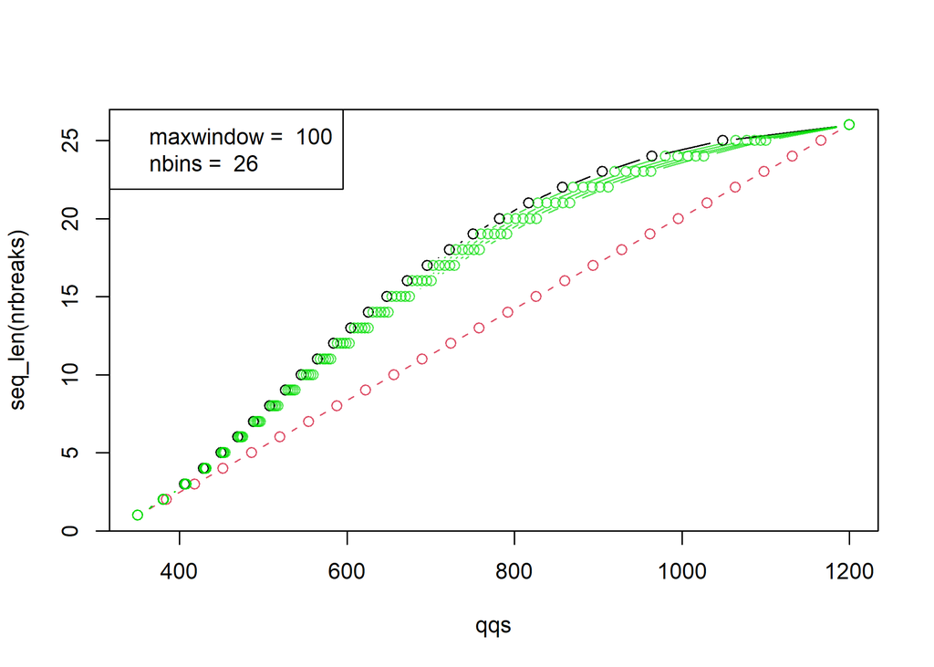

```r
cdsw$sampling_breaks(maxwindow = 100,plot = TRUE)
```

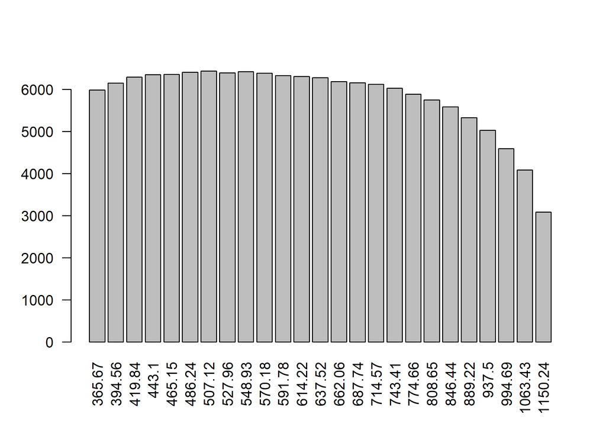

```r
cdsw$plot()
```

```r
knitr::kable(cdsw$asTable())
```

|  | from | to | mid | width | counts |
| --- | --- | --- | --- | --- | --- |
| 0% | 349.63 | 381.71 | 365.670 | 32.08 | 6113 |
| 4% | 380.71 | 408.41 | 394.560 | 27.70 | 6371 |
| 8% | 407.41 | 432.26 | 419.835 | 24.85 | 6578 |
| 12% | 431.26 | 454.93 | 443.095 | 23.67 | 6622 |
| 16% | 453.93 | 476.38 | 465.155 | 22.45 | 6625 |
| 20% | 475.38 | 497.11 | 486.245 | 21.73 | 6678 |
| 24% | 496.11 | 518.13 | 507.120 | 22.02 | 6763 |
| 28% | 517.13 | 538.79 | 527.960 | 21.66 | 6730 |
| 32% | 537.79 | 560.07 | 548.930 | 22.28 | 6771 |
| 36% | 559.07 | 581.30 | 570.185 | 22.23 | 6691 |
| 40% | 580.30 | 603.26 | 591.780 | 22.96 | 6621 |
| 44% | 602.26 | 626.18 | 614.220 | 23.92 | 6603 |
| 48% | 625.18 | 649.87 | 637.525 | 24.69 | 6572 |
| 52% | 648.87 | 675.24 | 662.055 | 26.37 | 6430 |
| 56% | 674.24 | 701.24 | 687.740 | 27.00 | 6402 |
| 60% | 700.24 | 728.90 | 714.570 | 28.66 | 6322 |
| 64% | 727.90 | 758.92 | 743.410 | 31.02 | 6244 |
| 68% | 757.92 | 791.39 | 774.655 | 33.47 | 6093 |
| 72% | 790.39 | 826.91 | 808.650 | 36.52 | 5891 |
| 76% | 825.91 | 866.98 | 846.445 | 41.07 | 5730 |
| 80% | 865.98 | 912.46 | 889.220 | 46.48 | 5469 |
| 84% | 911.46 | 963.54 | 937.500 | 52.08 | 5119 |
| 88% | 962.54 | 1026.85 | 994.695 | 64.31 | 4672 |
| 92% | 1025.85 | 1101.01 | 1063.430 | 75.16 | 4134 |
| 96% | 1100.01 | 1200.48 | 1150.245 | 100.47 | 3118 |

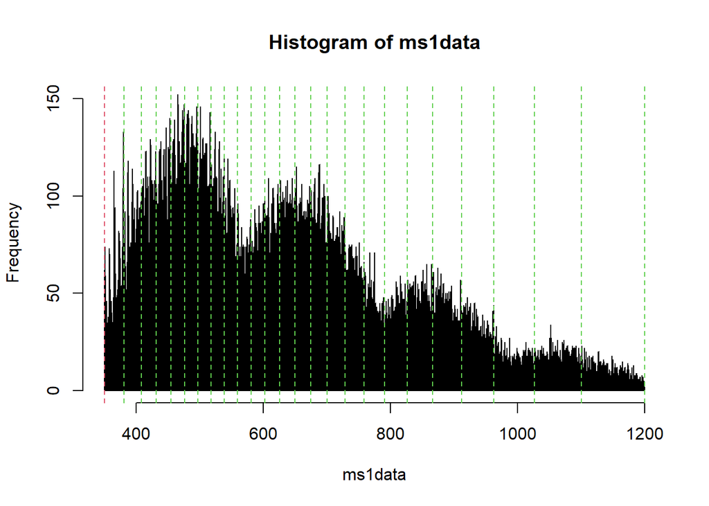

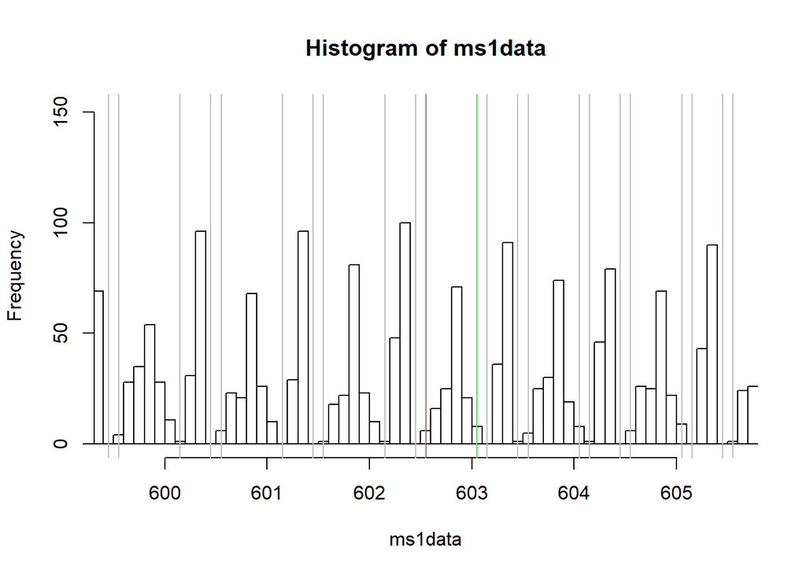

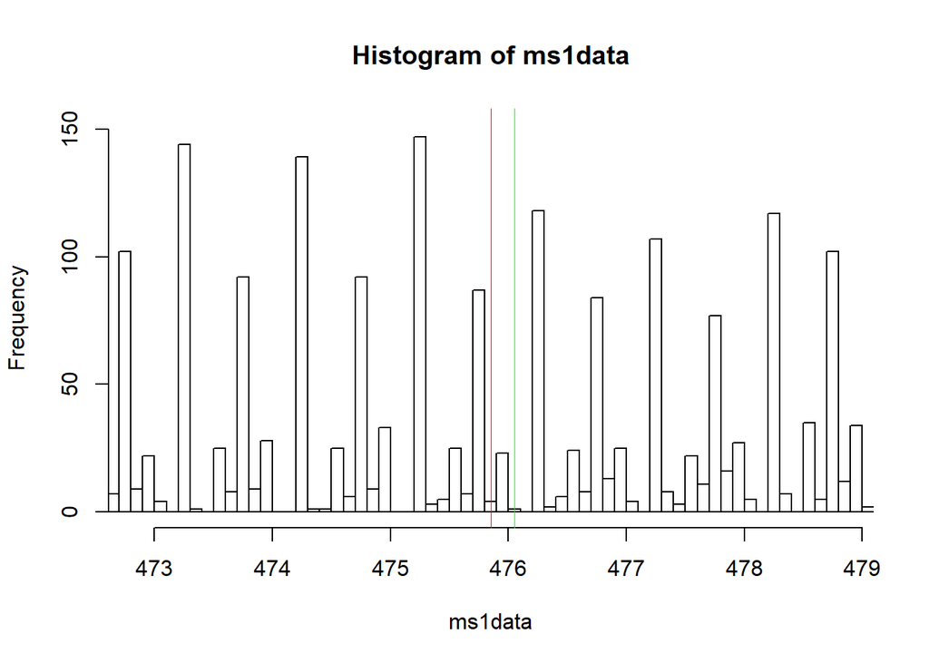

| from | to | mid | width | counts |
| --- | --- | --- | --- | --- |
| 350.13 | 381.35 | 365.74 | 31.22 | 6053 |
| 381.05 | 408.05 | 394.55 | 27.00 | 6191 |
| 407.65 | 432.05 | 419.85 | 24.40 | 6448 |
| 431.65 | 454.45 | 443.05 | 22.80 | 6448 |
| 454.35 | 476.05 | 465.20 | 21.70 | 6389 |
| 475.85 | 496.85 | 486.35 | 21.00 | 6526 |
| 496.45 | 517.85 | 507.15 | 21.40 | 6587 |
| 517.45 | 538.45 | 527.95 | 21.00 | 6492 |
| 538.15 | 560.05 | 549.10 | 21.90 | 6688 |
| 559.55 | 581.05 | 570.30 | 21.50 | 6482 |
| 580.55 | 603.05 | 591.80 | 22.50 | 6526 |
| 602.55 | 626.05 | 614.30 | 23.50 | 6452 |
| 625.55 | 649.45 | 637.50 | 23.90 | 6335 |
| 649.25 | 675.15 | 662.20 | 25.90 | 6392 |
| 674.55 | 701.15 | 687.85 | 26.60 | 6293 |
| 700.55 | 728.55 | 714.55 | 28.00 | 6160 |
| 728.25 | 758.55 | 743.40 | 30.30 | 6119 |
| 758.25 | 791.25 | 774.75 | 33.00 | 6038 |
| 790.65 | 826.55 | 808.60 | 35.90 | 5815 |
| 826.25 | 866.55 | 846.40 | 40.30 | 5622 |
| 866.35 | 912.05 | 889.20 | 45.70 | 5408 |
| 911.85 | 963.15 | 937.50 | 51.30 | 5055 |
| 962.75 | 1026.35 | 994.55 | 63.60 | 4631 |
| 1026.25 | 1100.65 | 1063.45 | 74.40 | 4105 |
| 1100.45 | 1200.05 | 1150.25 | 99.60 | 3091 |

```r
knitr::kable(cdsw$optimizeWindows(maxbin = 10, plot = TRUE) )
```

```r
mixedError <- cdsw$error()
```

# Benchmarking of the methods.

We compare the optimal number of MS1 peaks per SWATH window (same in each window) with the numbers obtained by using all of the 3 methods implemented.

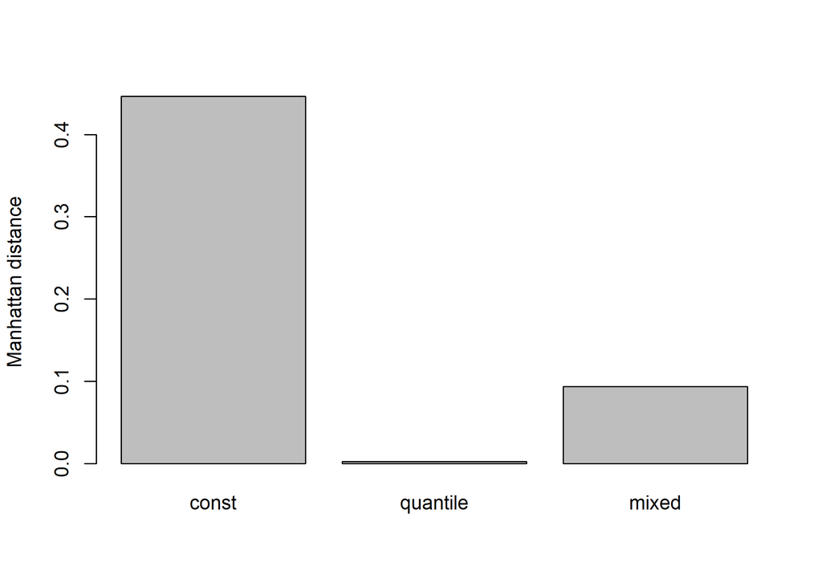

```r
barplot(c(const = constError$score1, quantile = quantileError$score1, mixed = mixedError$score1),ylab = "Manhattan distance")
```

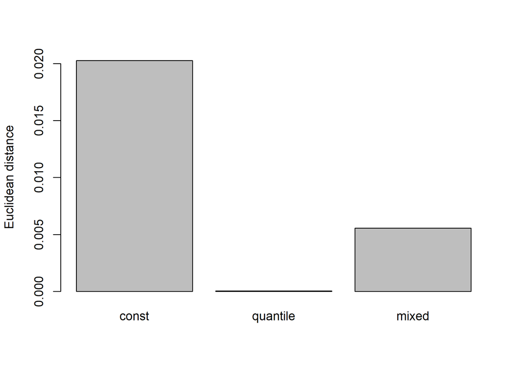

```r
barplot(c(const = constError$score2, quantile = quantileError$score2, mixed = mixedError$score2),ylab = "Euclidean distance")
```

We can see that Method 3 has a relatively small error although it is able to fulfill constraints such as maximum window size.